# Introduction

L’histoire du décryptage remonte à l’Antiquité avec des méthodes rudimentaires de substitution de lettres. Cependant, le véritable essor a eu lieu pendant la Seconde Guerre mondiale, avec des avancées majeures telles que le décryptage d’Enigma par les Alliés. L’informatique a ensuite révolutionné le domaine avec l’avènement de l’informatique quantique et de puissants algorithmes de chiffrement. Aujourd’hui, le décryptage est crucial pour la cybersécurité, la protection des données et la lutte contre la criminalité informatique, motivant constamment le développement de nouvelles techniques cryptographiques.

# Les données

Nous devons trouver un jeu de données de base à notre travail, pour cela nous avons choisi de sélectionner roman de **Marcel Proust**, soit *“Du côté de chez Swann”* comme texte de référence. Nous avons choisi ce livre car il est assez long et nous permettra d’avoir un jeu de données assez conséquent pour pouvoir travailler dessus.

Une fois notre base de données crée, nous transformons les lignes en une unique chaîne de caractère, supprimons tous les signes de ponctuation et plaçons les mots dans un vecteur.

Importation et Nettoyage de la base de données

```r
#Importation des jeux de données
swann <- readLines("swann.txt")
swann <- paste(swann, collapse = " ")
swann <- tolower(swann)

#On supprime la ponctuation du livre Swann
swann <- gsub("[[:punct:]]", " ", swann)

# On supprime le nom du personnage principal qui apparait trop souvent et peut fausser les statistiques
swann <- gsub(paste0("\\b", "swann", "\\b"), "", swann, ignore.case = T)

#Enfin on supprime les doubles espaces engendrer par la suppression de la ponctuation
swann <- gsub("  ", " ", swann)
```

# Analyse des fréquences d’apparition des lettres

Pour pouvoir décrypter nos messages nous devons tout d’abord analyser les fréquences d’apparition des paires de lettre dans le texte. Regardons toutes les paires de lettre possibles dans l’alphabet avec l’espace inclus.

```r
alphabet =c(letters," ")

paire <- function(alphabet){
  paire <- c()
  for (i in 1:length(alphabet)){
    for (j in 1:length(alphabet)){
      p <- paste0(alphabet[i],alphabet[j])
      paire = c(paire,p)
    }
  }
  return(paire)
}
comb_paire <- paire(alphabet)
```

On constate qu’il y a 729 paires de lettres possibles dans l’alphabet avec l’espace compris. Nous allons maintenant créer une matrice qui contient les fréquences d’apparitionde chaque paire de lettre dans le texte, pour voir lesquelles ressortent le plus souvent.

```r
library(stringr)
freq_paire <- function(paire,ch,alphabet){
  c_paire <- c()
  for (p in paire){c_paire <- c(c_paire, str_count(ch,p))}
  matrice_paire <- matrix(c_paire,nrow=length(alphabet),ncol=length(alphabet),byrow = T,list(alphabet, alphabet))
  matrice_freq <- matrice_paire / rowSums(matrice_paire)
  return(matrice_freq)
}

Q <- freq_paire(comb_paire,swann,alphabet)
```

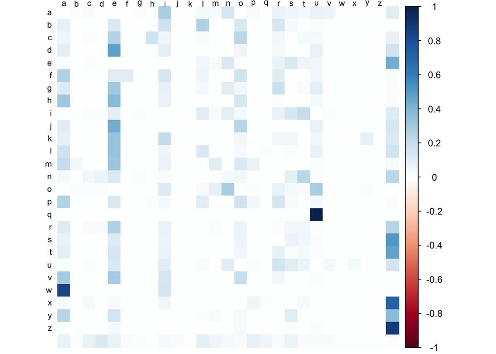

```r
library(corrplot)
corrplot(Q,
         method = "color",
         tl.col = "black",
         tl.cex = 0.7,
         tl.srt = 0)
```

Par exemple, grâce au graphique ci-dessus, on remarque que la lettre “q” est constamment suivie de la lettre “u”, ce qui est exact, car il n’existe pas de mot en français dans lequel la lettre “q” n’est pas suivie de “u”. On remarque également que le Z est généralement positionner a la fin d’un mot ce phénomène étant attribuable à la conjugaison des verbes à la deuxième personne du pluriel “vous” en français.

# 2. Création des fonctions de cryptage et calcul de la vraisemblance du texte décodé

La fonction de cryptage va nous permettre de coder le texte par substitution, le but etant d’associées chaque lettres a une autres et de les substitués entre elles Cette fonction nous servira également pour tester la vraisemblance de notre texte décodé durant le processus de decryptage, afin de calculer la vraisemblance d’une clé.

```r
# fonction pour crypter le texte chiffré
cryptage <- function(texte,cle){
  texte = tolower(texte)
  for (i in 1:nchar(texte)) {
    l = substring(texte,i,i)
    if (l != " "){substring(texte,i,i) = cle[[l]]}
  }
  return(texte)
}
```

[output not shown]

La fonction de vraisemblance va nous permettre de calculer la vraisemblance d’une clé, c’est à dire la probabilité d’observer le texte chiffré sachant la clé.

```r
#Fonction de log vraisemblance qui calcule la vraisemblance d'observer le texte chiffré
vraisemblance <- function(Code,mat){
  vrais <- 0
  for (i in 1:(nchar(Code)-1)){
    l1 <- substring(Code,i,i)
    l2 <- substring(Code,i+1,i+1)
    freq <- mat[l1, l2]
     vrais <- vrais + log(ifelse(freq > 0, freq, 1e-10)) # Si la valeur est nulle on la remplace par une valeur proche de 0 afin d'éviter le calcul de log(0)
    }
  return(vrais)
}
```

# Implémentation de l’algorithme de Metropolis Hastings

```r
algo_metropolis <- function(N, MsgCode,alphabet,mat) {
  cle_test <- setNames(sample(letters), letters) # Initialisation de la table de substitution avec des valeurs aléatoires
  meilleur_code <- cryptage(MsgCode,cle_test)
  meilleure_proba <- vraisemblance(meilleur_code,mat )

  for (i in 1:N) {
    # Génération d'une nouvelle clé en substituant deux lettres a la fois
    choix_lettres <- sample(1:26, 2) # choisir deux lettres à remplacer
    nouvelle_cle <- cle_test
    nouvelle_cle[[choix_lettres[1]]] <- cle_test[[choix_lettres[2]]]
    nouvelle_cle[choix_lettres[2]] <- cle_test[[choix_lettres[1]]]

    # On recupère ici le texte crypté avec la nouvelle clé puis on calcule sa vraisemblance
    prop_code <- cryptage(MsgCode,nouvelle_cle)
    prop_logprob <- vraisemblance(prop_code,mat)

    # Rejet / acceptation de cette nouvelle clé au regard de la vraisemblance
    if (runif(1) < exp(prop_logprob - meilleure_proba)) {
      cle_test <- nouvelle_cle
      meilleure_code <- prop_code
      meilleure_proba <- prop_logprob

      if (meilleure_proba > vraisemblance(meilleur_code,mat)) {
        meilleur_code <- prop_code
        meilleur_cle <- nouvelle_cle
      }

      # Affichage (toute les dix lignes) afin d'avoir le déroulement et le comportement de l'algorithme
      #if(i %% 10 == 0 ){cat( i,"-", meilleur_code, "\n")}
    }
  }
  return(list(cle_decodage = meilleur_cle, code_decrypte=meilleur_code))
}

resultat <- algo_metropolis(15000,texte_cry,alphabet,Q)
meileur_cle <- resultat$cle_decodage
meilleur_code <- resultat$code_decrypte
meilleur_code
```

```
## [1] "aujourd fui maman est morte ou peut etre fier je ne sais pas j ai recu un telegramme de l asile mere decedee enterrement demain sentiments distingues cela ne veut rien dire c etait peut etre fier"
```

Nous pouvons enfin comparer la clé de substitution obtenue avec la clé de substitution utilisée pour crypter le texte. clé de substitution utilisée pour crypter le texte

```r
vrai_cle
```

```
##   a   b   c   d   e   f   g   h   i   j   k   l   m   n   o   p   q   r   s   t
## "l" "y" "b" "s" "z" "h" "g" "q" "r" "o" "d" "p" "u" "f" "n" "c" "m" "e" "k" "t"
##   u   v   w   x   y   z
## "j" "i" "v" "a" "x" "w"
```

clé de substitution obtenue par l’algorithme de Metropolis Hastings

```r
meileur_cle
```

```
##   a   b   c   d   e   f   g   h   i   j   k   l   m   n   o   p   q   r   s   t
## "z" "c" "p" "w" "r" "n" "g" "q" "v" "u" "s" "a" "y" "o" "j" "l" "f" "i" "d" "t"
##   u   v   w   x   y   z
## "m" "h" "x" "k" "b" "e"
```

Nous pouvons calculer le pourcentage de lettres bien décodées par l’algorithme de Metropolis Hastings.

```r
liste_lettres_meilleur_code <- strsplit(meilleur_code, "")[[1]]
liste_lettre_texte_dec <- strsplit(tolower(texte_dec), "")[[1]]

nb_lettres_bien_decodees <- 0
for(i in 1:length(liste_lettres_meilleur_code)){
  if(liste_lettres_meilleur_code[[i]] == liste_lettre_texte_dec[[i]]){
    nb_lettres_bien_decodees <- nb_lettres_bien_decodees + 1
  }
}

pourcentage_lettres_bien_decodees <- round(nb_lettres_bien_decodees/length(liste_lettre_texte_dec)*100, 2)
paste("Pourcentage de lettres bien décodées : ", pourcentage_lettres_bien_decodees,"%")
```

```
## [1] "Pourcentage de lettres bien décodées :  98.46 %"
```